# Data Visualization for Policy Analysis: Assignment 4

Emma Peterson

10/13/2017

## Theme

```r
#set theme for all plots

my_theme <- theme(plot.background = element_rect(fill="#F4F4F4"),
                  plot.margin=unit(c(1,1,1,1),"cm"),
                  plot.caption = element_text(family="Montserrat Light", size=6,
                                              margin=margin(t=20)),
                  plot.title = element_text(family="Montserrat", face="bold", size=15),
                  plot.subtitle = element_text(family="Courier New"),

                  panel.background = element_rect(fill = "#F4F4F4"),
                  panel.grid.major.y = element_line(color="black", size=0.25),
                  panel.grid.minor.y = element_line(color="black", size=0.25),
                  panel.grid.minor.x=element_blank(),
                  panel.grid.major.x=element_blank(),

                  legend.background = element_rect(fill="#F4F4F4"),
                  legend.key = element_blank(),
                  legend.title = element_text(family="Montserrat", size=10),
                  legend.text = element_text(family="Courier New", size=8),

                  axis.ticks.y = element_blank(),
                  axis.ticks.x = element_blank(),
                  axis.text = element_text(family="Montserrat Light", size=7),
                  axis.text.x = element_text(angle = 45, hjust = 1, margin=margin(t=-10)),
                  axis.title = element_text(family="Montserrat", size=8),
                  axis.title.x = element_text(margin=margin(t=15)),
                  axis.title.y = element_text(margin=margin(r=15)))
```

## Plot 1

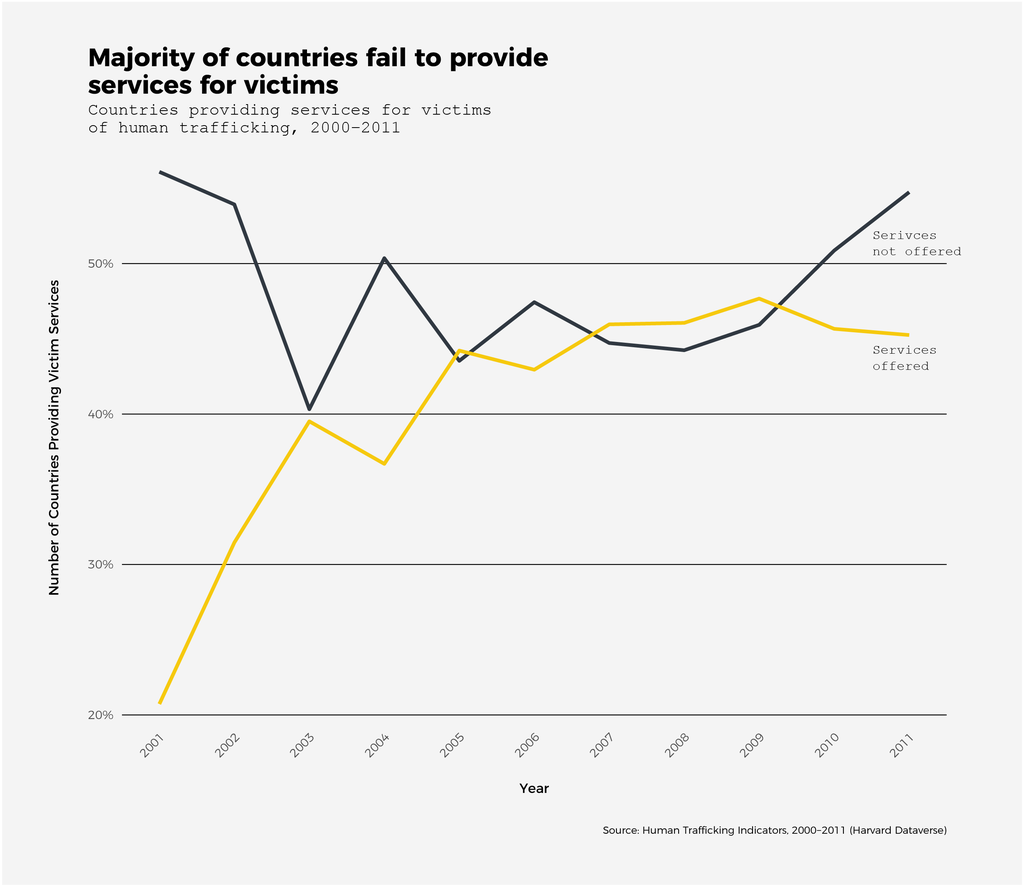

```r
ggplot(victim_services, aes(x=year, y=percentage, color=victimservices)) +

  geom_line(size=1) +

  labs(y = "Number of Countries Providing Victim Services", x = "Year",
       title="Majority of countries fail to provide \nservices for victims",
       subtitle="Countries providing services for victims \nof human trafficking, 2000-2011",
       caption="Source: Human Trafficking Indicators, 2000-2011 (Harvard Dataverse)") +

  scale_color_manual(name="Victim\nServices",
                       values=c("#303841", "#F6C90E"),
                       labels=c("Not Offered", "Offered")) +

  my_theme +

  theme(panel.grid.minor.y = element_blank(),
        axis.text.x = element_text(angle = 45, hjust = 1, margin=margin(t=-2))) +

  scale_x_continuous(breaks=seq(2001,2011),
                     labels=seq(2001,2011)) +

  scale_y_continuous(breaks=c(0.1, 0.2, 0.3, 0.4, 0.5, 0.6),
                     labels=c("10%", "20%", "30%", "40%", "50%", "60%"))
```

The initial sharp increase in countries providing services for victims of human trafficking may be a result of the adoption of the United Nations adoption of the *Palermo Protocol to Prevent, Suppress and Punish Trafficking in Persons, especially Women and Children* in 2000. Up until this point, human trafficking had not been formally defined on the international stage. However, even 17 years following its adoption, most countries continue to lack services for victims. It is yet unclear as to why recent years have demonstrated somewhat of a plateau – or perhaps even a reversal – in progress on this front.

## Plot 2

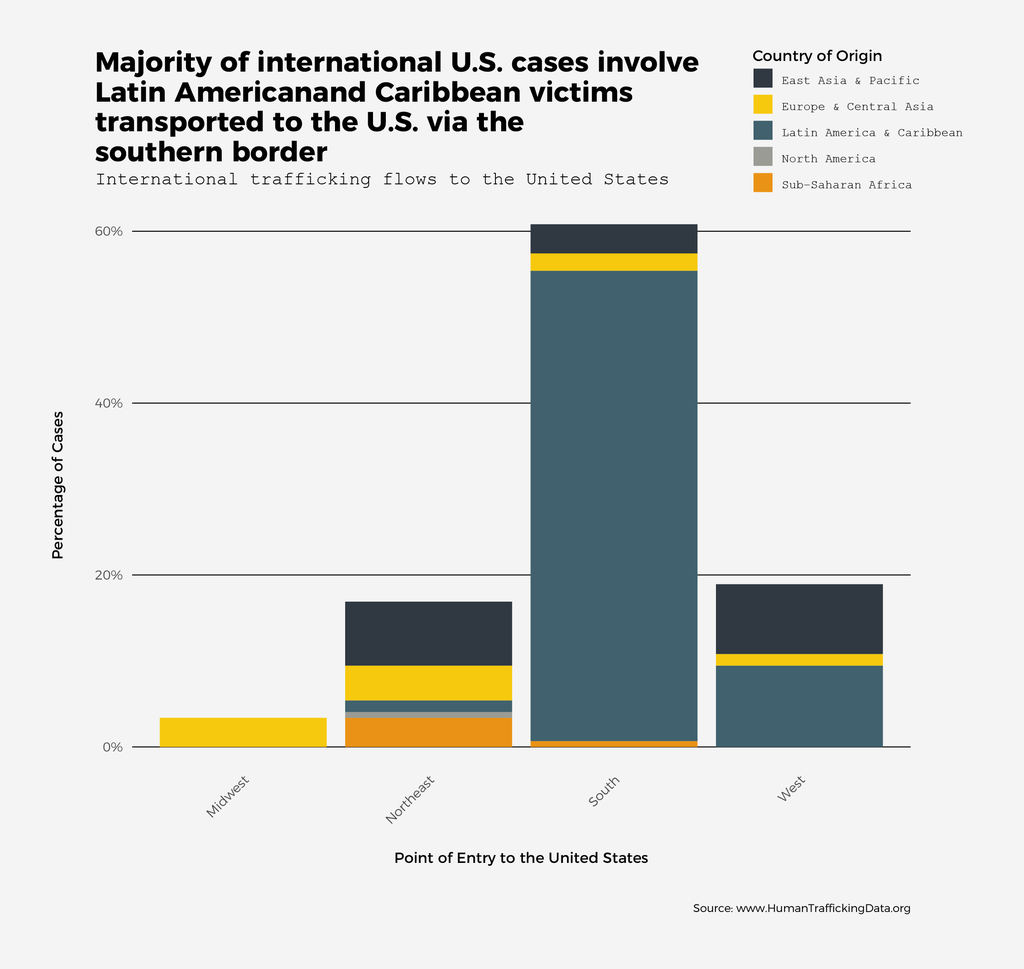

```r
ggplot(origin_entry, aes(x=region, fill=origin_region)) +

  geom_bar(aes(y = (..count..) / sum(..count..))) +

  labs(y = "Percentage of Cases", x = "Point of Entry to the United States",
       title=paste("Majority of international U.S. cases involve \nLatin American",
                   "and Caribbean victims \ntransported to the U.S. via the",
                   "\nsouthern border", sep=""),
       subtitle="International trafficking flows to the United States",
       caption="Source: www.HumanTraffickingData.org") +

  scale_fill_manual(name="Country of Origin",
                     values=c("#303841", "#F6C90E", "#40616d", "#9A9B94", "#EA9215"),
                     labels=c("East Asia & Pacific", "Europe & Central Asia",
                              "Latin America & Caribbean", "North America",
                              "Sub-Saharan Africa")) +

  my_theme +

  theme(panel.grid.minor.y = element_blank(),
        axis.text.x = element_text(margin=margin(t=-2))) +

  scale_x_discrete(labels=c("Midwest", "Northeast", "South", "West")) +
  scale_y_continuous(labels = c("0%", "20%", "40%", "60%"),
                     breaks = c(0, 0.2, 0.4, 0.6))
```

## Plot 3

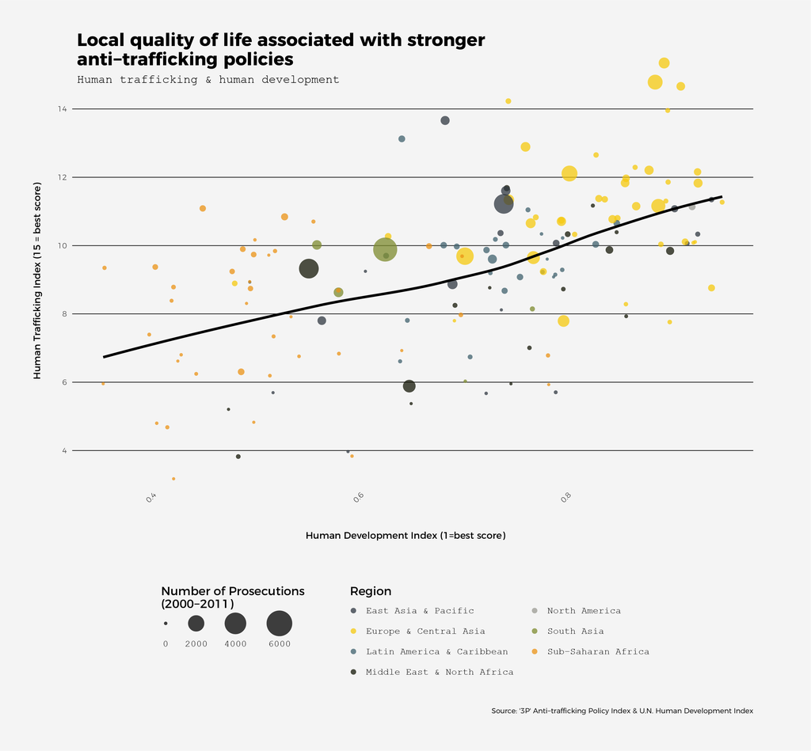

```r
ggplot(combined, aes(x=hdi_score, y=ht_index)) +
  geom_jitter(aes(color=region, size=prosecutions), alpha=0.75) +
  geom_smooth(se=FALSE, color="black") +

labs(y = "Human Trafficking Index (15 = best score)", x = "Human Development Index (1=best score)",
     title="Local quality of life associated with stronger \nanti-trafficking policies",
     subtitle="Human trafficking & human development",
     caption="Source: '3P' Anti-trafficking Policy Index & U.N. Human Development Index") +

  my_theme +

  theme(plot.subtitle = element_text(family="Courier New", margin=margin(b=10)),
        panel.grid.minor.y = element_blank(),
        legend.position = "bottom",
        legend.direction = "vertical",
        axis.text.x = element_text(angle = 45, hjust = 1, margin=margin(t=-10)),
        axis.title = element_text(family="Montserrat", size=8)) +

        scale_color_manual(name="Region",
                     values=c("#303841", "#F6C90E", "#40616d", "#141607",
                              "#9A9B94", "#7d8b2e", "#EA9215"),
                     labels=c("East Asia & Pacific", "Europe & Central Asia",
                              "Latin America & Caribbean", "Middle East & North Africa",
                              "North America", "South Asia", "Sub-Saharan Africa")) +
        scale_size_continuous(range=c(1,10), name="Number of Prosecutions \n(2000-2011)") +

        scale_y_continuous(breaks=c(4,6,8,10,12,14),
                           labels=c(4,6,8,10,12,14)) +

        scale_x_continuous(breaks=seq(0,1,by=0.2),
                           labels=seq(0,1,by=0.2))
```

The **3P Anti-trafficking Policy Index** was developed through the European Union, and aims to quantify the extent to which each country adheres to the requirements set forth by the United Nations *Palermo Protocol to Prevent, Suppress and Punish Trafficking in Persons, especially Women and Children*. Countries are given a score ranging from 1 (no compliance) to 5 (full compliance) on each of the following dimensions, for a total possible score of 15:

- Prosecution of perpetrators of human trafficking
- Prevention of human trafficking
- Protection of human trafficking victims

The **Human Development Index** was developed by the United Nations, and evaluates life expectancy at birth, average years of schooling, and gross national income per capita.

The tracking between these two indices may suggest that those countries with the resources to foster strong HDI scores are better equipped to comply with the Palermo Protocol. However, the variability in this trend is perhaps more interesting: why would two countries with similar HDI scores – even two countries in the same global region – differ in their willingness or ability to properly address human trafficking?

## Plot 4

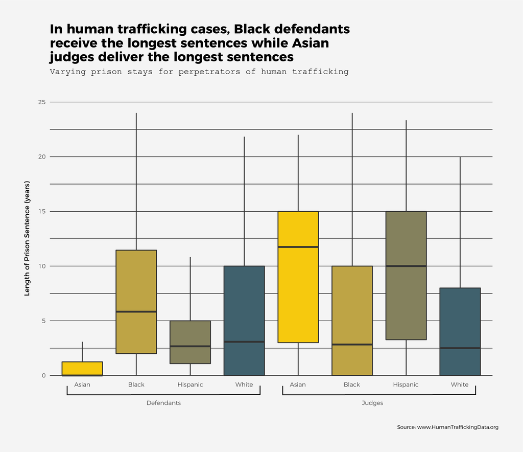

```r
ggplot(filter(traf, defendant_race != "indian" & defendant_race != "other")) +

  geom_boxplot(aes(x=judge_race, y=total_sentence, fill=judge_race),
               width=0.75, outlier.shape=NA) +

  geom_boxplot(aes(x=defendant_race, y=total_sentence, fill=defendant_race),
               width=0.75, outlier.shape=NA) +

  labs(y = "Length of Prison Sentence (years)",
       title=paste("In human trafficking cases, Black defendants",
                   "\nreceive the longest sentences while ",
                   "Asian \njudges deliver the longest sentences", sep=""),
       subtitle="Varying prison stays for perpetrators of human trafficking",
       caption="Source: www.HumanTraffickingData.org") +

  scale_fill_manual(name="Judge Race",
                    values=c("#262c33", "#546373", "#b3920a", "#f2c60e",
                             "#7f807a", "#bebfb6", "#bf7711", "#ff9f17"),
                    labels=c("Asian Defendant", "Asian Judge", "Black Defendant",
                             "Black Judge", "Hispanic Defendant", "Hispanic Judge",
                             "White Defendant", "White Judge")) +

  my_theme +

  theme(legend.position = "none",
        axis.title.x = element_blank()) +

  scale_y_continuous(limits=c(0, 25)) +

  guides(fill=guide_legend(keywidth=0.5, keyheight=1, default.unit="cm")) +

  scale_x_discrete(labels=c("Asian \ndefendant", "Asian \njudge",
                            "Black \ndefendant", "Black \njudge",
                            "Hispanic \ndefendant", "Hispanic \njudge",
                            "White \ndefendant", "White \njudge"))
```

Perpetrators of any crime should receive similar sentences regardless of their own race or that of their judge. This doesn’t appear to be the case for human trafficking. While the lengthier sentences received by Black defendants may be the result of the same racial bias that affects sentencing for other crimes, the variation in sentencing based on the race of the judge is perhaps more unusual. The median sentences delivered by Asian and Hispanic judges have been approximately **four times longer** than those delivered by White and Black judges. While the explanation for this is yet unknown, it is possible that Asian and Hispanic judges are more sympathetic to large numbers of Asian and Hispanic victims.

## Plot 5

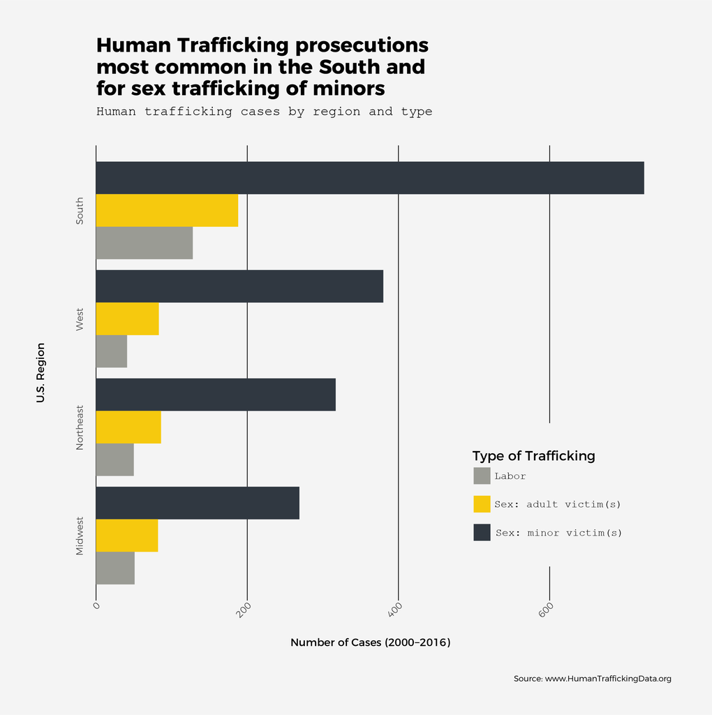

```r
ggplot(filter(case_loc, !is.na(region)), aes(x=region, fill=trafficking_type)) +
  geom_bar(aes(y = (..count..)), position="dodge") +
  coord_flip() +

  labs(y = "Number of Cases (2000-2016)", x = "U.S. Region",
       title=paste("Human Trafficking prosecutions \nmost common in the South ",
                   "and \nfor sex trafficking of minors", sep=""),
       subtitle="Human trafficking cases by region and type",
       caption="Source: www.HumanTraffickingData.org") +

  scale_fill_manual(name="Type of Trafficking",
                    values=c("#9A9B94", "#F6C90E", "#40616d"),
                    labels=c("Labor", "Sex: \nadult victim(s)",
                             "Sex: \nminor victim(s)")) +

  my_theme +

  theme(panel.grid.major.x = element_line(color="black", size=0.25),
        panel.grid.minor.y=element_blank(),
        panel.grid.major.y=element_blank(),
        axis.text.x = element_text(margin=margin(t=-2))) +

  guides(fill=guide_legend(keywidth=0.5, keyheight=0.5, default.unit="cm")) +
  scale_x_discrete(labels=c("Midwest", "Northeast", "West", "South"))
```

With a large majority of foreign victims entering the U.S. through the south, it makes sense that the largest number of human trafficking lawsuits has occurred in the south. However, the fact that sex trafficking cases greatly outnumber labor trafficking cases may be problematic. A 2005 study by the International Labour Organization found that less that half of worldwide trafficking victims are victims of sex trafficking. Either the U.S. diverges from that trend, or labor trafficking cases are not making their way to the courts for one reason or another.

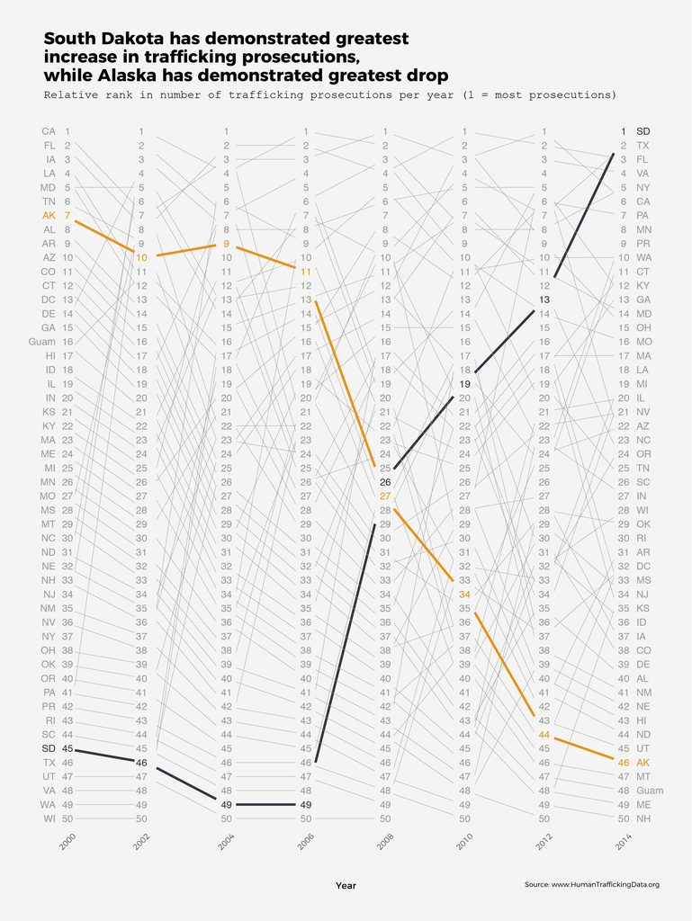

```r
ggslopegraph(state_by_year_wide,  offset.x = 0.13,
             yrev = TRUE, col.lines = cols, col.lab = cols,
             col.num=cols, lwd=widths,
             xlab = "Year",
             ylab = "Rank in HT Prosecutions (1=most prosecutions)") +

  labs(title="South Dakota has demonstrated greatest \nincrease in trafficking prosecutions, \nwhile Alaska has demonstrated greatest drop",
       subtitle="State rankings in number of trafficking prosecutions per year",
       caption="Source: www.HumanTraffickingData.org") +

  theme(axis.title.y = element_text(margin=margin(r=0))) +
    my_theme
```

While many of these rankings demonstrate fairly large year-to-year changes, Alaska and South Dakota stand out as having experienced the largest decrease and increase, respectively, in human trafficking cases since 2000. It is not immediately clear whether these shifts are primarily the result of changes in human trafficking patterns or changes in enforcement. It should also be noted that some states demonstrate relatively large jumps up and down the rankings, while others have remained fairly consistent over time. The reasons for this are yet unknown.

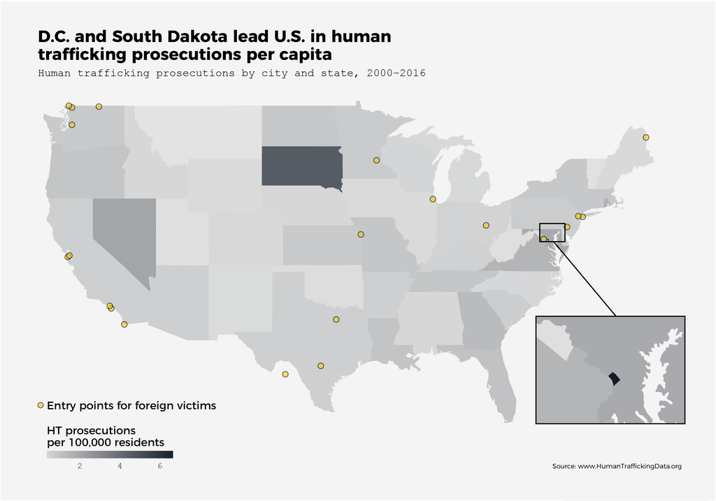

```r
ggplot() +
  geom_polygon(data=us_counts, aes(x=long, y=lat,
                                   group = group, fill=us_counts$relative_count)) +
  my_theme +
  labs(fill = "Number of HT prosecutions \nper 100,000 residents",
       title = "South Dakota and D.C. lead U.S. in human \ntrafficking prosecutions per capita", x="", y="",
       subtitle = "Number of human trafficking prosecutions per 100,000 residents, 2000-2016",
       caption="Source: www.HumanTraffickingData.org") +
  scale_y_continuous(breaks=c()) +
  scale_x_continuous(breaks=c()) +
  theme(panel.border =  element_blank(),
        legend.position = "bottom") +
  scale_fill_gradient(low="#E3E3E3", high = "#141C25", guide = guide_colorbar(direction = "horizontal", ticks=FALSE, barwidth = 8, barheight = 0.5))
```

Two areas have deviated from the norm in terms of the volume of human trafficking cases they have processed since 2000: South Dakota, and Washington, D.C. While other states have processed significantly more cases in an absolute sense, controlling for population brings these two areas to light. It is again not immediately clear whether this pattern is driven by differences in enforcement or by actual trafficking patterns, though a quick search brings up articles like “Why sex traffickers love South Dakota” and “Washington D.C.’s serious sex-trafficking problem”.

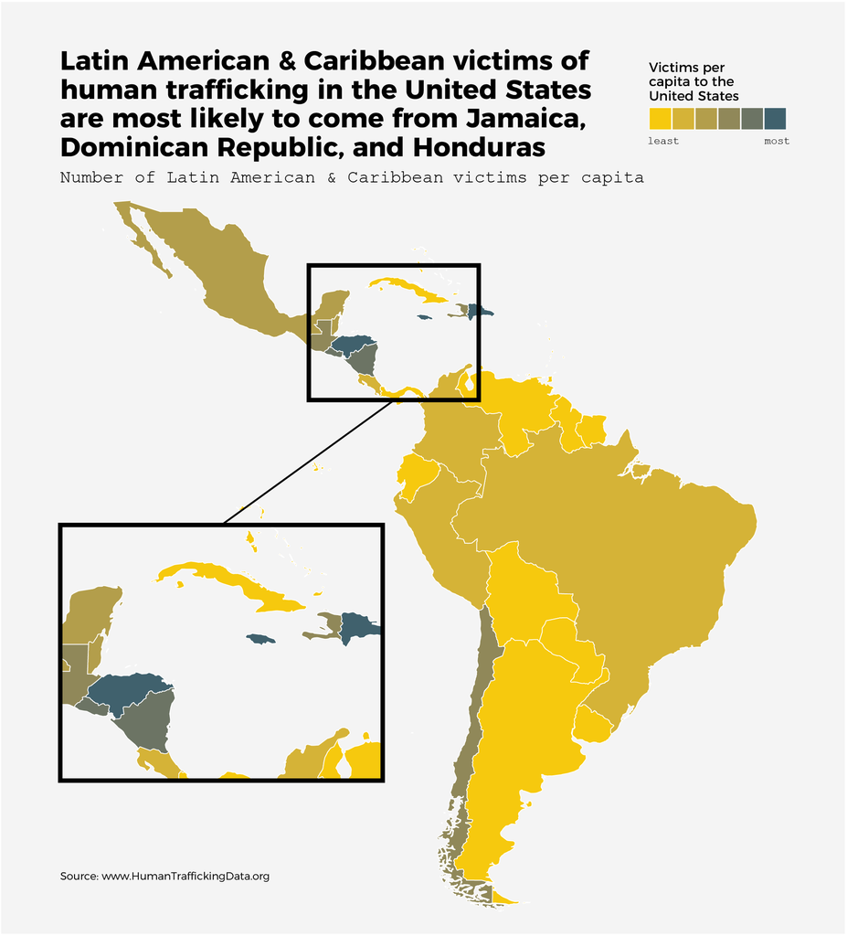

```r
ggplot(data = countries.df, aes(x = long,
                                y = lat,
                                group = group,
                                fill=pop_bucket)) +
  geom_polygon(color = "white", size=0.2) +
  coord_quickmap(xlim=c(-125, -30), ylim=(c(-60, 35))) +
  scale_fill_manual(
                    values = c('#f6c90e','#d5b337','#b39e4b',
                               '#908859','#6c7464','#40616d'),
                    labels = c('least (0)', '', '', '', '', 'most \n(0.000057+)')) +

  labs(fill = "Victims per \ncapita to the \nUnited States",
       title = paste("Latin American & Caribbean victims of \nhuman trafficking in the",
                      "United States \nare most likely to come from",
                      "Jamaica, \nDominican Republic, and Honduras"),
       x="",
       y="",
       subtitle = "Number of Latin American & Caribbean \nvictims per capita",
       caption="Source: www.HumanTraffickingData.org") +

  my_theme +

  scale_y_continuous(breaks=c()) +
  scale_x_continuous(breaks=c())
```